# Temporal Event-Detection Analysis

## Saunders Cox

### Goal:

Identify how sick Twitter users from Blacksburg get during the transition from the end of Summer into the beginning of Autumn. Using keywords that users use such as "sick", "fever", and "flu" that were used on various days during the time period covered by the data using a vector space model matrix using TFDIF, we can estimate a trend. Perhaps we can even foresee when students, athletes, and workers of Blacksburg should take the most precautions to stay healthy throughout flu season. We can assume that not all keywords mentioned will be generated due to an actual ailment. However we can hypothesize that the words will pop up more following August and perhaps continue onward through October.

```python
import pandas as pd
import numpy as np

data = pd.read_csv('VT_tweets_2019Fall_geo.csv')
```

```python
data
```

|  | tweet | username | datetime | tweet_type | latitude | longitude | id |
| --- | --- | --- | --- | --- | --- | --- | --- |
| 0 | RT @WhitBabcock: I’d like to announce that I’v... | GTisSWARMING | 2019-08-25 00:00:14+00:00 | retweet | 0.0 | 0.0 | 1165413539248558081 |
| 1 | @miatiana_ &amp; was ... | ThatGuyMikee_ | 2019-08-25 00:00:37+00:00 | reply | 0.0 | 0.0 | 1165413633263919104 |
| 2 | RT @FuenteFootball: I love seeing Miami fail. | JJ_Stin | 2019-08-25 00:00:40+00:00 | retweet | 0.0 | 0.0 | 1165413645490282496 |
| 3 | https://t.co/lGpZzk5S1S | gagecdot | 2019-08-25 00:01:29+00:00 | original | 0.0 | 0.0 | 1165413854337216512 |
| 4 | @JimNagy_SB @RachelBaribeau @CanesFootball @Tr... | hokieprorichie | 2019-08-25 00:01:52+00:00 | reply | 0.0 | 0.0 | 1165413950739099648 |
| 5 | @AllAboutThisHoo This Miami the coastal favori... | FuenteFootball | 2019-08-25 00:01:57+00:00 | reply | 0.0 | 0.0 | 1165413971618390017 |
| 6 | RT @HokiesWBB: ▶️ Foreign Tour Vlog Ep. 5 🛶 O... | TheGoatBoy3 | 2019-08-25 00:03:49+00:00 | retweet | 0.0 | 0.0 | 1165414440289865728 |
| 7 | #whirlpoolturtle and the #bhsmarchingband sou... | KenPeaseART | 2019-08-25 00:03:50+00:00 | original | 0.0 | 0.0 | 1165414445583147008 |
| 8 | @OX_VT https://t.co/itcG56YZ00 | DrunkHokieBird | 2019-08-25 00:03:59+00:00 | reply | 0.0 | 0.0 | 1165414483004657664 |
| 9 | @StewartalsopIII Yes. It challenges certainty. | ClayNichols | 2019-08-25 00:04:17+00:00 | reply | 0.0 | 0.0 | 1165414557394845700 |
| 10 | RNK issues Area Forecast Discussion (AFD) at A... | iembot_rnk | 2019-08-25 00:05:07+00:00 | original | 0.0 | 0.0 | 1165414766799544321 |
| 11 | Two UF guys had it and were down. | VTFritz | 2019-08-25 00:05:18+00:00 | original | 0.0 | 0.0 | 1165414814212116482 |
| 12 | @BossHardy202 Payton rookie how much? | altizerac | 2019-08-25 00:05:22+00:00 | reply | 0.0 | 0.0 | 1165414831652069376 |
| 13 | Eliza: oh it’s slippery Victor: yo that’s me... | Overheard72 | 2019-08-25 00:06:17+00:00 | original | 0.0 | 0.0 | 1165415060073779201 |
| 14 | Victors ass is probably good - Liv | Overheard72 | 2019-08-25 00:06:30+00:00 | original | 0.0 | 0.0 | 1165415113676992512 |
| 15 | Yup. Hill made the RB drop it lol. All Hill do... | FuenteFootball | 2019-08-25 00:07:13+00:00 | quote | 0.0 | 0.0 | 1165415294841630721 |
| 16 | Can’t wait til we don’t score here. | CassellCaptain | 2019-08-25 00:07:50+00:00 | original | 0.0 | 0.0 | 1165415452174180353 |
| 17 | @JoshuaPotash @frannie1225 “Whites women for t... | KenStevie1 | 2019-08-25 00:08:06+00:00 | reply | 0.0 | 0.0 | 1165415517370368002 |
| 18 | RT @FuenteFootball: Trevon Hill starting beef?... | jlow003 | 2019-08-25 00:08:34+00:00 | retweet | 0.0 | 0.0 | 1165415634680918016 |
| 19 | RT @1071PSK: @VGcom will be this weeksbguest o... | Nmharley2 | 2019-08-25 00:09:55+00:00 | retweet | 0.0 | 0.0 | 1165415977137446913 |
| 20 | @Nicole_Cliffe @thebestjasmine @emmastraub I w... | laurapy | 2019-08-25 00:10:14+00:00 | reply | 0.0 | 0.0 | 1165416053398286337 |
| 21 | forget going to the gym, walking to my classes... | julesoreilly | 2019-08-25 00:10:18+00:00 | original | 0.0 | 0.0 | 1165416073375731712 |
| 22 | Ik y’all caught that lil pause 😭 https://t.co/... | NaudiaStill | 2019-08-25 00:12:07+00:00 | quote | 0.0 | 0.0 | 1165416530621976576 |
| 23 | RT @sarah_rowann: my last brain cell getting r... | HannahBugxox | 2019-08-25 00:12:09+00:00 | retweet | 0.0 | 0.0 | 1165416535076343808 |
| 24 | @SaysHummingbird But will they?????!! | KenStevie1 | 2019-08-25 00:12:18+00:00 | reply | 0.0 | 0.0 | 1165416574435700736 |
| 25 | @thePhDandMe Does Saturday night count? Thats ... | brunsma | 2019-08-25 00:12:58+00:00 | reply | 0.0 | 0.0 | 1165416741025079299 |
| 26 | @CharlesMBlow That’s a rhetorical question isn... | KenStevie1 | 2019-08-25 00:13:21+00:00 | reply | 0.0 | 0.0 | 1165416840249729029 |
| 27 | The naked men, will rise - Victor | Overheard72 | 2019-08-25 00:15:00+00:00 | original | 0.0 | 0.0 | 1165417252428111872 |
| 28 | Another life just lost in #Illinois. #POTUS, p... | mikedien | 2019-08-25 00:15:12+00:00 | original | 0.0 | 0.0 | 1165417304437534720 |
| 29 | RT @johnlewis: Now I can think of nothing else... | emathern2008 | 2019-08-25 00:17:19+00:00 | retweet | 0.0 | 0.0 | 1165417837088739328 |
| ... | ... | ... | ... | ... | ... | ... | ... |
| 171736 | Drugs aren’t too hard if you study really well | Noelotov | 2019-10-25 01:39:04+00:00 | original | 0.0 | 0.0 | 1187544071696465924 |
| 171737 | @MichaelSReith1 @jrstoddard Thanks, btw, I am ... | RediscHumility | 2019-10-25 01:39:32+00:00 | reply | 0.0 | 0.0 | 1187544188734361600 |
| 171738 | RT @ChrisColemanTSL: Average number off/def sn... | cbord4 | 2019-10-25 01:39:38+00:00 | retweet | 0.0 | 0.0 | 1187544210976710663 |
| 171739 | WHERE my barbz at tonight??? | mvenuti_99 | 2019-10-25 01:39:45+00:00 | original | 0.0 | 0.0 | 1187544242203303936 |
| 171740 | RT @3304Sports: .@HokiesWSoccer comes from beh... | HoopBoys17 | 2019-10-25 01:40:25+00:00 | retweet | 0.0 | 0.0 | 1187544410717863936 |
| 171741 | i’m really in a tough spot and need some answe... | ElysiaCook5 | 2019-10-25 01:41:22+00:00 | original | 0.0 | 0.0 | 1187544649549918208 |
| 171742 | speed is not too bad for WiFi w/802.11ac-Wired... | MacTipsDaily | 2019-10-25 01:41:33+00:00 | original | 0.0 | 0.0 | 1187544695301382145 |
| 171743 | I wrote this poem based on an @atlasobscura ar... | erinlyndal | 2019-10-25 01:41:36+00:00 | original | 0.0 | 0.0 | 1187544707838234625 |
| 171744 | @goMSUbuttboy69 Look I better not see any MSU ... | dnrx01 | 2019-10-25 01:41:38+00:00 | reply | 0.0 | 0.0 | 1187544717464080386 |
| 171745 | RT @lino_lupinetti: Florida boys are built dif... | RecruitSouth | 2019-10-25 01:41:44+00:00 | retweet | 0.0 | 0.0 | 1187544740125990912 |
| 171746 | @julynlb Always with you babe... you know who ... | mvenuti_99 | 2019-10-25 01:41:44+00:00 | reply | 0.0 | 0.0 | 1187544740226621440 |
| 171747 | @A_YoungGoodman I love it | AndrewAlixRadio | 2019-10-25 01:41:45+00:00 | reply | 0.0 | 0.0 | 1187544743967895552 |
| 171748 | RT @clasticdetritus: reminder — @vtgeosciences... | specklight | 2019-10-25 01:42:19+00:00 | retweet | 0.0 | 0.0 | 1187544886213365765 |
| 171749 | RT @3304Sports: .@HokiesWSoccer wins 2-1 from ... | Ty_Katz | 2019-10-25 01:42:54+00:00 | retweet | 0.0 | 0.0 | 1187545034616381440 |
| 171750 | When you’re at the bar and they’re showing the... | jordyyyyy96 | 2019-10-25 01:43:03+00:00 | original | 0.0 | 0.0 | 1187545073317232642 |
| 171751 | Restorative Justice Training with RPCP. So mu... | blueroadsedu | 2019-10-25 01:43:11+00:00 | original | 0.0 | 0.0 | 1187545105214910466 |
| 171752 | RT @blkayrforce1: School hard so I’m starting ... | wauxmd | 2019-10-25 01:43:50+00:00 | retweet | 0.0 | 0.0 | 1187545267698053121 |
| 171753 | RT @ManeetChh: DAVID CUNNINGHAM ON THE CALL ht... | ryan_jordan2 | 2019-10-25 01:44:40+00:00 | retweet | 0.0 | 0.0 | 1187545478608621574 |
| 171754 | Evidently https://t.co/9JXw3C7fTy (Netflix's s... | MacTipsDaily | 2019-10-25 01:45:05+00:00 | original | 0.0 | 0.0 | 1187545584158330886 |
| 171755 | @TheoryWOContext I'm huffy that there are no l... | derekhennen | 2019-10-25 01:45:37+00:00 | reply | 0.0 | 0.0 | 1187545720095756288 |
| 171756 | @NoahJ456 Xbox One :) | vV_killdawg_Vv | 2019-10-25 01:45:42+00:00 | reply | 0.0 | 0.0 | 1187545738307424266 |
| 171757 | This SMU game is on crack | henryskutt | 2019-10-25 01:46:16+00:00 | original | 0.0 | 0.0 | 1187545881010200577 |
| 171758 | @MichaelSReith1 @jrstoddard Ugh, sorry for poo... | RediscHumility | 2019-10-25 01:46:17+00:00 | reply | 0.0 | 0.0 | 1187545887599419392 |
| 171759 | Looks like I won't be streaming BO4 zombies to... | TheKappaKobe | 2019-10-25 01:46:48+00:00 | original | 0.0 | 0.0 | 1187546016020647936 |
| 171760 | when are we boycotting the scooters | cmj_madden | 2019-10-25 01:47:07+00:00 | original | 0.0 | 0.0 | 1187546096853291013 |
| 171761 | Exploring data structures can beat random fore... | xwj06 | 2019-10-25 01:47:27+00:00 | original | 0.0 | 0.0 | 1187546180592586752 |
| 171762 | what’s a hokie https://t.co/i5gAlVAygB | EmilyYando | 2019-10-25 01:48:26+00:00 | original | 0.0 | 0.0 | 1187546425611165696 |
| 171763 | RT @EmilyYando: what’s a hokie https://t.co/i5... | emilyplun | 2019-10-25 01:49:20+00:00 | retweet | 0.0 | 0.0 | 1187546655022821376 |
| 171764 | @_stephingstone i WISH my fingers were breadst... | drewgouge | 2019-10-25 01:49:28+00:00 | reply | 0.0 | 0.0 | 1187546687889215488 |
| 171765 | BO3 for tonight since BO4 servers are down too... | TheKappaKobe | 2019-10-25 01:49:52+00:00 | original | 0.0 | 0.0 | 1187546787290198017 |

171766 rows × 7 columns

### Filter

```python
# We need to get individual dates, so we can get that from datetime
data['date'] = [i[:10] for i in data.datetime]
data
```

|  | tweet | username | datetime | tweet_type | latitude | longitude | id | date |
| --- | --- | --- | --- | --- | --- | --- | --- | --- |
| 0 | RT @WhitBabcock: I’d like to announce that I’v... | GTisSWARMING | 2019-08-25 00:00:14+00:00 | retweet | 0.0 | 0.0 | 1165413539248558081 | 2019-08-25 |
| 1 | @miatiana_ &amp; was ... | ThatGuyMikee_ | 2019-08-25 00:00:37+00:00 | reply | 0.0 | 0.0 | 1165413633263919104 | 2019-08-25 |
| 2 | RT @FuenteFootball: I love seeing Miami fail. | JJ_Stin | 2019-08-25 00:00:40+00:00 | retweet | 0.0 | 0.0 | 1165413645490282496 | 2019-08-25 |
| 3 | https://t.co/lGpZzk5S1S | gagecdot | 2019-08-25 00:01:29+00:00 | original | 0.0 | 0.0 | 1165413854337216512 | 2019-08-25 |
| 4 | @JimNagy_SB @RachelBaribeau @CanesFootball @Tr... | hokieprorichie | 2019-08-25 00:01:52+00:00 | reply | 0.0 | 0.0 | 1165413950739099648 | 2019-08-25 |
| 5 | @AllAboutThisHoo This Miami the coastal favori... | FuenteFootball | 2019-08-25 00:01:57+00:00 | reply | 0.0 | 0.0 | 1165413971618390017 | 2019-08-25 |
| 6 | RT @HokiesWBB: ▶️ Foreign Tour Vlog Ep. 5 🛶 O... | TheGoatBoy3 | 2019-08-25 00:03:49+00:00 | retweet | 0.0 | 0.0 | 1165414440289865728 | 2019-08-25 |
| 7 | #whirlpoolturtle and the #bhsmarchingband sou... | KenPeaseART | 2019-08-25 00:03:50+00:00 | original | 0.0 | 0.0 | 1165414445583147008 | 2019-08-25 |
| 8 | @OX_VT https://t.co/itcG56YZ00 | DrunkHokieBird | 2019-08-25 00:03:59+00:00 | reply | 0.0 | 0.0 | 1165414483004657664 | 2019-08-25 |
| 9 | @StewartalsopIII Yes. It challenges certainty. | ClayNichols | 2019-08-25 00:04:17+00:00 | reply | 0.0 | 0.0 | 1165414557394845700 | 2019-08-25 |
| 10 | RNK issues Area Forecast Discussion (AFD) at A... | iembot_rnk | 2019-08-25 00:05:07+00:00 | original | 0.0 | 0.0 | 1165414766799544321 | 2019-08-25 |
| 11 | Two UF guys had it and were down. | VTFritz | 2019-08-25 00:05:18+00:00 | original | 0.0 | 0.0 | 1165414814212116482 | 2019-08-25 |
| 12 | @BossHardy202 Payton rookie how much? | altizerac | 2019-08-25 00:05:22+00:00 | reply | 0.0 | 0.0 | 1165414831652069376 | 2019-08-25 |
| 13 | Eliza: oh it’s slippery Victor: yo that’s me... | Overheard72 | 2019-08-25 00:06:17+00:00 | original | 0.0 | 0.0 | 1165415060073779201 | 2019-08-25 |
| 14 | Victors ass is probably good - Liv | Overheard72 | 2019-08-25 00:06:30+00:00 | original | 0.0 | 0.0 | 1165415113676992512 | 2019-08-25 |
| 15 | Yup. Hill made the RB drop it lol. All Hill do... | FuenteFootball | 2019-08-25 00:07:13+00:00 | quote | 0.0 | 0.0 | 1165415294841630721 | 2019-08-25 |
| 16 | Can’t wait til we don’t score here. | CassellCaptain | 2019-08-25 00:07:50+00:00 | original | 0.0 | 0.0 | 1165415452174180353 | 2019-08-25 |
| 17 | @JoshuaPotash @frannie1225 “Whites women for t... | KenStevie1 | 2019-08-25 00:08:06+00:00 | reply | 0.0 | 0.0 | 1165415517370368002 | 2019-08-25 |
| 18 | RT @FuenteFootball: Trevon Hill starting beef?... | jlow003 | 2019-08-25 00:08:34+00:00 | retweet | 0.0 | 0.0 | 1165415634680918016 | 2019-08-25 |
| 19 | RT @1071PSK: @VGcom will be this weeksbguest o... | Nmharley2 | 2019-08-25 00:09:55+00:00 | retweet | 0.0 | 0.0 | 1165415977137446913 | 2019-08-25 |
| 20 | @Nicole_Cliffe @thebestjasmine @emmastraub I w... | laurapy | 2019-08-25 00:10:14+00:00 | reply | 0.0 | 0.0 | 1165416053398286337 | 2019-08-25 |
| 21 | forget going to the gym, walking to my classes... | julesoreilly | 2019-08-25 00:10:18+00:00 | original | 0.0 | 0.0 | 1165416073375731712 | 2019-08-25 |
| 22 | Ik y’all caught that lil pause 😭 https://t.co/... | NaudiaStill | 2019-08-25 00:12:07+00:00 | quote | 0.0 | 0.0 | 1165416530621976576 | 2019-08-25 |
| 23 | RT @sarah_rowann: my last brain cell getting r... | HannahBugxox | 2019-08-25 00:12:09+00:00 | retweet | 0.0 | 0.0 | 1165416535076343808 | 2019-08-25 |
| 24 | @SaysHummingbird But will they?????!! | KenStevie1 | 2019-08-25 00:12:18+00:00 | reply | 0.0 | 0.0 | 1165416574435700736 | 2019-08-25 |
| 25 | @thePhDandMe Does Saturday night count? Thats ... | brunsma | 2019-08-25 00:12:58+00:00 | reply | 0.0 | 0.0 | 1165416741025079299 | 2019-08-25 |
| 26 | @CharlesMBlow That’s a rhetorical question isn... | KenStevie1 | 2019-08-25 00:13:21+00:00 | reply | 0.0 | 0.0 | 1165416840249729029 | 2019-08-25 |
| 27 | The naked men, will rise - Victor | Overheard72 | 2019-08-25 00:15:00+00:00 | original | 0.0 | 0.0 | 1165417252428111872 | 2019-08-25 |
| 28 | Another life just lost in #Illinois. #POTUS, p... | mikedien | 2019-08-25 00:15:12+00:00 | original | 0.0 | 0.0 | 1165417304437534720 | 2019-08-25 |
| 29 | RT @johnlewis: Now I can think of nothing else... | emathern2008 | 2019-08-25 00:17:19+00:00 | retweet | 0.0 | 0.0 | 1165417837088739328 | 2019-08-25 |
| ... | ... | ... | ... | ... | ... | ... | ... | ... |
| 171736 | Drugs aren’t too hard if you study really well | Noelotov | 2019-10-25 01:39:04+00:00 | original | 0.0 | 0.0 | 1187544071696465924 | 2019-10-25 |
| 171737 | @MichaelSReith1 @jrstoddard Thanks, btw, I am ... | RediscHumility | 2019-10-25 01:39:32+00:00 | reply | 0.0 | 0.0 | 1187544188734361600 | 2019-10-25 |
| 171738 | RT @ChrisColemanTSL: Average number off/def sn... | cbord4 | 2019-10-25 01:39:38+00:00 | retweet | 0.0 | 0.0 | 1187544210976710663 | 2019-10-25 |
| 171739 | WHERE my barbz at tonight??? | mvenuti_99 | 2019-10-25 01:39:45+00:00 | original | 0.0 | 0.0 | 1187544242203303936 | 2019-10-25 |
| 171740 | RT @3304Sports: .@HokiesWSoccer comes from beh... | HoopBoys17 | 2019-10-25 01:40:25+00:00 | retweet | 0.0 | 0.0 | 1187544410717863936 | 2019-10-25 |
| 171741 | i’m really in a tough spot and need some answe... | ElysiaCook5 | 2019-10-25 01:41:22+00:00 | original | 0.0 | 0.0 | 1187544649549918208 | 2019-10-25 |
| 171742 | speed is not too bad for WiFi w/802.11ac-Wired... | MacTipsDaily | 2019-10-25 01:41:33+00:00 | original | 0.0 | 0.0 | 1187544695301382145 | 2019-10-25 |
| 171743 | I wrote this poem based on an @atlasobscura ar... | erinlyndal | 2019-10-25 01:41:36+00:00 | original | 0.0 | 0.0 | 1187544707838234625 | 2019-10-25 |
| 171744 | @goMSUbuttboy69 Look I better not see any MSU ... | dnrx01 | 2019-10-25 01:41:38+00:00 | reply | 0.0 | 0.0 | 1187544717464080386 | 2019-10-25 |
| 171745 | RT @lino_lupinetti: Florida boys are built dif... | RecruitSouth | 2019-10-25 01:41:44+00:00 | retweet | 0.0 | 0.0 | 1187544740125990912 | 2019-10-25 |
| 171746 | @julynlb Always with you babe... you know who ... | mvenuti_99 | 2019-10-25 01:41:44+00:00 | reply | 0.0 | 0.0 | 1187544740226621440 | 2019-10-25 |
| 171747 | @A_YoungGoodman I love it | AndrewAlixRadio | 2019-10-25 01:41:45+00:00 | reply | 0.0 | 0.0 | 1187544743967895552 | 2019-10-25 |
| 171748 | RT @clasticdetritus: reminder — @vtgeosciences... | specklight | 2019-10-25 01:42:19+00:00 | retweet | 0.0 | 0.0 | 1187544886213365765 | 2019-10-25 |
| 171749 | RT @3304Sports: .@HokiesWSoccer wins 2-1 from ... | Ty_Katz | 2019-10-25 01:42:54+00:00 | retweet | 0.0 | 0.0 | 1187545034616381440 | 2019-10-25 |
| 171750 | When you’re at the bar and they’re showing the... | jordyyyyy96 | 2019-10-25 01:43:03+00:00 | original | 0.0 | 0.0 | 1187545073317232642 | 2019-10-25 |
| 171751 | Restorative Justice Training with RPCP. So mu... | blueroadsedu | 2019-10-25 01:43:11+00:00 | original | 0.0 | 0.0 | 1187545105214910466 | 2019-10-25 |
| 171752 | RT @blkayrforce1: School hard so I’m starting ... | wauxmd | 2019-10-25 01:43:50+00:00 | retweet | 0.0 | 0.0 | 1187545267698053121 | 2019-10-25 |
| 171753 | RT @ManeetChh: DAVID CUNNINGHAM ON THE CALL ht... | ryan_jordan2 | 2019-10-25 01:44:40+00:00 | retweet | 0.0 | 0.0 | 1187545478608621574 | 2019-10-25 |
| 171754 | Evidently https://t.co/9JXw3C7fTy (Netflix's s... | MacTipsDaily | 2019-10-25 01:45:05+00:00 | original | 0.0 | 0.0 | 1187545584158330886 | 2019-10-25 |
| 171755 | @TheoryWOContext I'm huffy that there are no l... | derekhennen | 2019-10-25 01:45:37+00:00 | reply | 0.0 | 0.0 | 1187545720095756288 | 2019-10-25 |
| 171756 | @NoahJ456 Xbox One :) | vV_killdawg_Vv | 2019-10-25 01:45:42+00:00 | reply | 0.0 | 0.0 | 1187545738307424266 | 2019-10-25 |
| 171757 | This SMU game is on crack | henryskutt | 2019-10-25 01:46:16+00:00 | original | 0.0 | 0.0 | 1187545881010200577 | 2019-10-25 |
| 171758 | @MichaelSReith1 @jrstoddard Ugh, sorry for poo... | RediscHumility | 2019-10-25 01:46:17+00:00 | reply | 0.0 | 0.0 | 1187545887599419392 | 2019-10-25 |
| 171759 | Looks like I won't be streaming BO4 zombies to... | TheKappaKobe | 2019-10-25 01:46:48+00:00 | original | 0.0 | 0.0 | 1187546016020647936 | 2019-10-25 |
| 171760 | when are we boycotting the scooters | cmj_madden | 2019-10-25 01:47:07+00:00 | original | 0.0 | 0.0 | 1187546096853291013 | 2019-10-25 |
| 171761 | Exploring data structures can beat random fore... | xwj06 | 2019-10-25 01:47:27+00:00 | original | 0.0 | 0.0 | 1187546180592586752 | 2019-10-25 |
| 171762 | what’s a hokie https://t.co/i5gAlVAygB | EmilyYando | 2019-10-25 01:48:26+00:00 | original | 0.0 | 0.0 | 1187546425611165696 | 2019-10-25 |
| 171763 | RT @EmilyYando: what’s a hokie https://t.co/i5... | emilyplun | 2019-10-25 01:49:20+00:00 | retweet | 0.0 | 0.0 | 1187546655022821376 | 2019-10-25 |
| 171764 | @_stephingstone i WISH my fingers were breadst... | drewgouge | 2019-10-25 01:49:28+00:00 | reply | 0.0 | 0.0 | 1187546687889215488 | 2019-10-25 |
| 171765 | BO3 for tonight since BO4 servers are down too... | TheKappaKobe | 2019-10-25 01:49:52+00:00 | original | 0.0 | 0.0 | 1187546787290198017 | 2019-10-25 |

171766 rows × 8 columns

```python
# Now we group the tweets by date
g = data.groupby('date')
freqs = g.size()
freqs
```

```
date
2019-08-25    1968
2019-08-26    2962
2019-08-27    2733
2019-08-28    2920
2019-08-29    3156
2019-08-30    2962
2019-08-31    4298
2019-09-01    2062
2019-09-02    1940
2019-09-03    2296
2019-09-04    2309
2019-09-05    2598
2019-09-06    2949
2019-09-07    3653
2019-09-08    2595
2019-09-09    2593
2019-09-10    2536
2019-09-11    2668
2019-09-12    2612
2019-09-13    2549
2019-09-14    3493
2019-09-15    2395
2019-09-16    2332
2019-09-17    2341
2019-09-18    2528
2019-09-19    2389
2019-09-20    2469
2019-09-21    2159
2019-09-22    2107
2019-09-23    2275
              ...
2019-09-26    3209
2019-09-27    3462
2019-09-28    4113
2019-09-29    2135
2019-09-30    2589
2019-10-01    3589
2019-10-02    2994
2019-10-03    2639
```

[output cut: 8 more lines]

```
2019-10-12    2950
2019-10-13    2161
2019-10-14    2430
2019-10-15    3794
2019-10-16    3629
2019-10-17    2608
2019-10-18    2418
2019-10-19    4011
2019-10-20    4613
2019-10-21    3030
2019-10-22    3382
2019-10-23    3056
2019-10-24    2732
2019-10-25     223
Length: 62, dtype: int64
```

```python
# Then we can have individual words for each tweet
import string

def removePunct(str):
    punctuation = '!"#$%&\()*+,-—./:;<=>?@\[\\]^_`{|}~'
    for x in punctuation:
        str = str.replace(x, '')
    return str.lower()

data['bag'] = data.tweet.map(lambda t: removePunct(t).split())
```

```python
data.bag
```

```
0         [rt, whitbabcock, i’d, like, to, announce, tha...
1                                      [miatiana, amp, was]
2         [rt, fuentefootball, i, love, seeing, miami, f...
3                                      [httpstcolgpzzk5s1s]
4         [jimnagysb, rachelbaribeau, canesfootball, tre...
5         [allaboutthishoo, this, miami, the, coastal, f...
6         [rt, hokieswbb, ▶️, foreign, tour, vlog, ep, 5...
7         [whirlpoolturtle, and, the, bhsmarchingband, s...
8                                [oxvt, httpstcoitcg56yz00]
9         [stewartalsopiii, yes, it, challenges, certainty]
10        [rnk, issues, area, forecast, discussion, afd,...
11                [two, uf, guys, had, it, and, were, down]
12                [bosshardy202, payton, rookie, how, much]
13        [eliza, oh, it’s, slippery, victor, yo, that’s...
14                  [victors, ass, is, probably, good, liv]
```

[output cut: 47 more lines]

```python
# Then we can put all the words into each date
import itertools
dates = g.bag.aggregate(lambda listofbags:
                list(itertools.chain.from_iterable(listofbags)))
len(dates)
```

```
62
```

```python
dates
```

```
date
2019-08-25    [rt, whitbabcock, i’d, like, to, announce, tha...
2019-08-26    [rt, abdulmueenbogis, جسر, بمنطقة, changsha, m...
2019-08-27    [🥳🥳🥳dbartelstein, httpstco1swcve73xj, rt, virg...
2019-08-28    [rt, sallycmorton, science, can’t, wait, we, n...
2019-08-29    [join, us, friday, august, 30, from, 46pm, at,...
2019-08-30    [rt, gayhokie, my, first, day, of, classes, as...
2019-08-31    [kuttipiee, thank, you, bb, 🥰, rt, michaelsutp...
2019-09-01    [hokienc86, theblackgatsby, if, you, benched, ...
2019-09-02    [the, brad, miller, game, i, just, watched, a,...
2019-09-03    [rt, therealestmuto, so, bryce, harper, has, t...
2019-09-04    [pivettahype, nolawheelerhamelsarrietavargas, ...
2019-09-05    [rt, therealestmuto, so, bryce, harper, has, t...
2019-09-06    [rt, lolofennec, here’s, a, personal, question...
2019-09-07    [sorry, rice, double, play, rt, hokiesfb, let'...
2019-09-08    [rt, dapdraw, hokie, breadsticks, are, going, ...
2019-09-09    [rt, blacksheepvt, when, i, try, to, log, back...
2019-09-10    [🚨, giveaway, alert, 🚨, coxcomm, is, bringing,...
2019-09-11    [rt, gettingaroundvt, on, your, left, remember...
2019-09-12    [oh, my, god, matz, get, it, together, bring, ...
2019-09-13    [congratulations, to, delterrykilgore, deltpil...
2019-09-14    [boosting, because, this, seems, to, be, a, ma...
2019-09-15    [rt, therealestmuto, braves, won't, make, the,...
2019-09-16    [seemeno, those, do, look, really, cool, you'r...
2019-09-17    [kindergarten, kiddos, sang, the, caterpillar,...
2019-09-18    [📣, coxcomm, is, bringing, you, closer, to, th...
2019-09-19    [today, during, the, 2019, ulifall, meeting, v...
2019-09-20    [rt, virginiatech, trinityapp, this, is, not, ...
2019-09-21    [rt, isabellshoptaw, life, hacks, httpstcojagd...
2019-09-22    [hell, yes, baby, uhhhhhhhhhhhhhhh, indycarpod...
2019-09-23    [092219, 1945, 801, university, city, blvd, ge...
                                    ...
2019-09-26    [❤, httpstco2m7yh825zo, wheeler, for, 590ish, ...
2019-09-27    [💡, light, show, 💡, 📱, open, your, hokie, ligh...
2019-09-28    [rt, henryskutt, pictured, virginia, tech, stu...
2019-09-29    [11, briggs, is, sent, to, the, brig, for, hol...
2019-09-30    [kayleepeterson7, i’m, all, yours, any, night,...
2019-10-01    [parrissanders, thats, a, bar, rt, henryskutt,...
2019-10-02    [thekitchenista, i, admire, your, optimism, so...
2019-10-03    [rt, vthomecoming, our, queen, candidate, of, ...
```

[output cut: 8 more lines]

```
2019-10-12    [rt, dimesadozenn, a, thing, happened, today, ...
2019-10-13    [rt, ctsportstalk, final, virginia, tech, 34, ...
2019-10-14    [rt, whitbabcock, today’s, best, headgear, sec...
2019-10-15    [you, guys, still, have, time, to, raise, 50, ...
2019-10-16    [maxontwitter, httpstcoltu26x1uyw, great, sltw...
2019-10-17    [dwayne, schintzius, was, one, of, the, random...
2019-10-18    [jimmyjomjom, httpstcokai3adbmwb, rt, rickgoge...
2019-10-19    [my, week, on, twitter, 🎉, 27, likes, 4, retwe...
2019-10-20    [rt, blacksheepvt, this, can't, be, real, http...
2019-10-21    [rt, fuentefootball, this, team, is, only, los...
2019-10-22    [get, ready, for, taja, cole, this, season, 🤩👌...
2019-10-23    [rt, henryskutt, vt, fans, when, the, football...
2019-10-24    [santilin99, was, the, corner, man, deliriumbu...
2019-10-25    [my, dad, is, going, to, come, down, for, game...
Name: bag, Length: 62, dtype: object
```

```python
# We build our Term Frequency from our counts of words from each day of the data
TF = dates.iloc[0:len(dates)].apply(
    lambda bag: pd.Series(bag).value_counts())
TF
```

| date | the | rt | a | to | for | i | and | is | of | in | ... | fagitaboutit | httpstcodm71uck405 | httpstcoj7q6kbzfkl | dispics | httpstcoize2wkembo | thecutch22 | httpstcoiah7uwzrck | httpstcocvprdqedc1 | marketable | httpstcokby483fmz9 |
| --- | --- | --- | --- | --- | --- | --- | --- | --- | --- | --- | --- | --- | --- | --- | --- | --- | --- | --- | --- | --- | --- |
| 2019-08-25 | 794.0 | 650.0 | 506.0 | 490.0 | 437.0 | 377.0 | 370.0 | 354.0 | 348.0 | 284.0 | ... | NaN | NaN | NaN | NaN | NaN | NaN | NaN | NaN | NaN | NaN |
| 2019-08-26 | 1387.0 | 1235.0 | 1022.0 | 981.0 | 533.0 | 530.0 | 662.0 | 679.0 | 707.0 | 443.0 | ... | NaN | NaN | NaN | NaN | NaN | NaN | NaN | NaN | NaN | NaN |
| 2019-08-27 | 1490.0 | 1067.0 | 822.0 | 877.0 | 549.0 | 547.0 | 673.0 | 441.0 | 569.0 | 586.0 | ... | NaN | NaN | NaN | NaN | NaN | NaN | NaN | NaN | NaN | NaN |
| 2019-08-28 | 1901.0 | 1249.0 | 953.0 | 1239.0 | 474.0 | 623.0 | 826.0 | 537.0 | 621.0 | 637.0 | ... | NaN | NaN | NaN | NaN | NaN | NaN | NaN | NaN | NaN | NaN |
| 2019-08-29 | 1656.0 | 1346.0 | 1048.0 | 1219.0 | 514.0 | 549.0 | 680.0 | 508.0 | 677.0 | 770.0 | ... | NaN | NaN | NaN | NaN | NaN | NaN | NaN | NaN | NaN | NaN |
| 2019-08-30 | 1467.0 | 1233.0 | 1056.0 | 812.0 | 581.0 | 523.0 | 617.0 | 492.0 | 590.0 | 691.0 | ... | NaN | NaN | NaN | NaN | NaN | NaN | NaN | NaN | NaN | NaN |
| 2019-08-31 | 2343.0 | 1680.0 | 1236.0 | 1192.0 | 717.0 | 660.0 | 834.0 | 711.0 | 605.0 | 779.0 | ... | NaN | NaN | NaN | NaN | NaN | NaN | NaN | NaN | NaN | NaN |
| 2019-09-01 | 1100.0 | 679.0 | 642.0 | 592.0 | 283.0 | 469.0 | 495.0 | 331.0 | 467.0 | 373.0 | ... | NaN | NaN | NaN | NaN | NaN | NaN | NaN | NaN | NaN | NaN |
| 2019-09-02 | 1033.0 | 560.0 | 554.0 | 626.0 | 337.0 | 462.0 | 489.0 | 313.0 | 379.0 | 368.0 | ... | NaN | NaN | NaN | NaN | NaN | NaN | NaN | NaN | NaN | NaN |
| 2019-09-03 | 1269.0 | 853.0 | 621.0 | 890.0 | 423.0 | 412.0 | 563.0 | 358.0 | 526.0 | 409.0 | ... | NaN | NaN | NaN | NaN | NaN | NaN | NaN | NaN | NaN | NaN |
| 2019-09-04 | 1199.0 | 731.0 | 790.0 | 799.0 | 456.0 | 434.0 | 596.0 | 333.0 | 431.0 | 521.0 | ... | NaN | NaN | NaN | NaN | NaN | NaN | NaN | NaN | NaN | NaN |
| 2019-09-05 | 1421.0 | 914.0 | 845.0 | 875.0 | 437.0 | 465.0 | 655.0 | 452.0 | 575.0 | 494.0 | ... | NaN | NaN | NaN | NaN | NaN | NaN | NaN | NaN | NaN | NaN |
| 2019-09-06 | 1384.0 | 1131.0 | 700.0 | 959.0 | 620.0 | 533.0 | 677.0 | 598.0 | 605.0 | 452.0 | ... | NaN | NaN | NaN | NaN | NaN | NaN | NaN | NaN | NaN | NaN |
| 2019-09-07 | 1694.0 | 1323.0 | 1006.0 | 992.0 | 620.0 | 589.0 | 710.0 | 606.0 | 532.0 | 587.0 | ... | NaN | NaN | NaN | NaN | NaN | NaN | NaN | NaN | NaN | NaN |
| 2019-09-08 | 1115.0 | 847.0 | 659.0 | 735.0 | 388.0 | 595.0 | 483.0 | 454.0 | 402.0 | 398.0 | ... | NaN | NaN | NaN | NaN | NaN | NaN | NaN | NaN | NaN | NaN |
| 2019-09-09 | 1244.0 | 982.0 | 748.0 | 853.0 | 702.0 | 462.0 | 822.0 | 380.0 | 421.0 | 510.0 | ... | NaN | NaN | NaN | NaN | NaN | NaN | NaN | NaN | NaN | NaN |
| 2019-09-10 | 1142.0 | 841.0 | 739.0 | 1089.0 | 416.0 | 542.0 | 729.0 | 429.0 | 436.0 | 499.0 | ... | NaN | NaN | NaN | NaN | NaN | NaN | NaN | NaN | NaN | NaN |
| 2019-09-11 | 1256.0 | 1036.0 | 834.0 | 1144.0 | 482.0 | 531.0 | 767.0 | 412.0 | 513.0 | 542.0 | ... | NaN | NaN | NaN | NaN | NaN | NaN | NaN | NaN | NaN | NaN |
| 2019-09-12 | 1164.0 | 892.0 | 787.0 | 854.0 | 475.0 | 524.0 | 657.0 | 407.0 | 483.0 | 453.0 | ... | NaN | NaN | NaN | NaN | NaN | NaN | NaN | NaN | NaN | NaN |
| 2019-09-13 | 1190.0 | 786.0 | 803.0 | 799.0 | 363.0 | 447.0 | 641.0 | 448.0 | 537.0 | 488.0 | ... | NaN | NaN | NaN | NaN | NaN | NaN | NaN | NaN | NaN | NaN |
| 2019-09-14 | 1970.0 | 1226.0 | 1118.0 | 1148.0 | 665.0 | 541.0 | 740.0 | 594.0 | 632.0 | 600.0 | ... | NaN | NaN | NaN | NaN | NaN | NaN | NaN | NaN | NaN | NaN |
| 2019-09-15 | 1269.0 | 613.0 | 742.0 | 762.0 | 363.0 | 538.0 | 543.0 | 445.0 | 385.0 | 498.0 | ... | NaN | NaN | NaN | NaN | NaN | NaN | NaN | NaN | NaN | NaN |
| 2019-09-16 | 1143.0 | 727.0 | 635.0 | 790.0 | 398.0 | 518.0 | 637.0 | 417.0 | 487.0 | 507.0 | ... | NaN | NaN | NaN | NaN | NaN | NaN | NaN | NaN | NaN | NaN |
| 2019-09-17 | 1116.0 | 835.0 | 632.0 | 753.0 | 432.0 | 517.0 | 631.0 | 439.0 | 428.0 | 391.0 | ... | NaN | NaN | NaN | NaN | NaN | NaN | NaN | NaN | NaN | NaN |
| 2019-09-18 | 1294.0 | 854.0 | 705.0 | 980.0 | 440.0 | 511.0 | 680.0 | 562.0 | 476.0 | 448.0 | ... | NaN | NaN | NaN | NaN | NaN | NaN | NaN | NaN | NaN | NaN |
| 2019-09-19 | 1078.0 | 796.0 | 658.0 | 895.0 | 414.0 | 415.0 | 556.0 | 482.0 | 459.0 | 508.0 | ... | NaN | NaN | NaN | NaN | NaN | NaN | NaN | NaN | NaN | NaN |
| 2019-09-20 | 1360.0 | 845.0 | 817.0 | 892.0 | 466.0 | 467.0 | 697.0 | 474.0 | 713.0 | 609.0 | ... | NaN | NaN | NaN | NaN | NaN | NaN | NaN | NaN | NaN | NaN |
| 2019-09-21 | 1099.0 | 661.0 | 605.0 | 718.0 | 350.0 | 406.0 | 492.0 | 435.0 | 568.0 | 424.0 | ... | NaN | NaN | NaN | NaN | NaN | NaN | NaN | NaN | NaN | NaN |
| 2019-09-22 | 847.0 | 504.0 | 446.0 | 603.0 | 284.0 | 418.0 | 415.0 | 323.0 | 333.0 | 285.0 | ... | NaN | NaN | NaN | NaN | NaN | NaN | NaN | NaN | NaN | NaN |
| 2019-09-23 | 1228.0 | 730.0 | 723.0 | 755.0 | 323.0 | 530.0 | 569.0 | 660.0 | 471.0 | 451.0 | ... | NaN | NaN | NaN | NaN | NaN | NaN | NaN | NaN | NaN | NaN |
| ... | ... | ... | ... | ... | ... | ... | ... | ... | ... | ... | ... | ... | ... | ... | ... | ... | ... | ... | ... | ... | ... |
| 2019-09-26 | 1421.0 | 1354.0 | 1269.0 | 1487.0 | 538.0 | 586.0 | 726.0 | 595.0 | 656.0 | 660.0 | ... | NaN | NaN | NaN | NaN | NaN | NaN | NaN | NaN | NaN | NaN |
| 2019-09-27 | 1785.0 | 1460.0 | 1301.0 | 1496.0 | 555.0 | 509.0 | 654.0 | 738.0 | 611.0 | 640.0 | ... | NaN | NaN | NaN | NaN | NaN | NaN | NaN | NaN | NaN | NaN |
| 2019-09-28 | 2182.0 | 1640.0 | 1128.0 | 1445.0 | 593.0 | 670.0 | 981.0 | 705.0 | 747.0 | 668.0 | ... | NaN | NaN | NaN | NaN | NaN | NaN | NaN | NaN | NaN | NaN |
| 2019-09-29 | 1062.0 | 504.0 | 648.0 | 639.0 | 368.0 | 506.0 | 532.0 | 431.0 | 384.0 | 362.0 | ... | NaN | NaN | NaN | NaN | NaN | NaN | NaN | NaN | NaN | NaN |
| 2019-09-30 | 1314.0 | 733.0 | 748.0 | 952.0 | 427.0 | 469.0 | 615.0 | 518.0 | 418.0 | 458.0 | ... | NaN | NaN | NaN | NaN | NaN | NaN | NaN | NaN | NaN | NaN |
| 2019-10-01 | 2149.0 | 1628.0 | 821.0 | 1871.0 | 889.0 | 818.0 | 783.0 | 516.0 | 909.0 | 622.0 | ... | NaN | NaN | NaN | NaN | NaN | NaN | NaN | NaN | NaN | NaN |
| 2019-10-02 | 1702.0 | 1096.0 | 889.0 | 1044.0 | 481.0 | 737.0 | 880.0 | 430.0 | 847.0 | 567.0 | ... | NaN | NaN | NaN | NaN | NaN | NaN | NaN | NaN | NaN | NaN |
| 2019-10-03 | 1358.0 | 819.0 | 933.0 | 844.0 | 448.0 | 614.0 | 685.0 | 385.0 | 650.0 | 495.0 | ... | NaN | NaN | NaN | NaN | NaN | NaN | NaN | NaN | NaN | NaN |
| 2019-10-04 | 1240.0 | 696.0 | 737.0 | 847.0 | 368.0 | 371.0 | 589.0 | 408.0 | 500.0 | 538.0 | ... | NaN | NaN | NaN | NaN | NaN | NaN | NaN | NaN | NaN | NaN |
| 2019-10-05 | 2501.0 | 1958.0 | 1200.0 | 1282.0 | 532.0 | 707.0 | 743.0 | 905.0 | 601.0 | 687.0 | ... | NaN | NaN | NaN | NaN | NaN | NaN | NaN | NaN | NaN | NaN |
| 2019-10-06 | 1604.0 | 1024.0 | 759.0 | 873.0 | 338.0 | 472.0 | 486.0 | 451.0 | 488.0 | 455.0 | ... | NaN | NaN | NaN | NaN | NaN | NaN | NaN | NaN | NaN | NaN |
| 2019-10-07 | 1267.0 | 622.0 | 626.0 | 771.0 | 419.0 | 516.0 | 579.0 | 415.0 | 520.0 | 486.0 | ... | NaN | NaN | NaN | NaN | NaN | NaN | NaN | NaN | NaN | NaN |
| 2019-10-08 | 1522.0 | 761.0 | 708.0 | 963.0 | 445.0 | 586.0 | 686.0 | 433.0 | 556.0 | 619.0 | ... | NaN | NaN | NaN | NaN | NaN | NaN | NaN | NaN | NaN | NaN |
| 2019-10-09 | 1363.0 | 833.0 | 800.0 | 802.0 | 413.0 | 567.0 | 666.0 | 401.0 | 525.0 | 480.0 | ... | NaN | NaN | NaN | NaN | NaN | NaN | NaN | NaN | NaN | NaN |
| 2019-10-10 | 1470.0 | 774.0 | 739.0 | 897.0 | 490.0 | 623.0 | 652.0 | 445.0 | 594.0 | 509.0 | ... | NaN | NaN | NaN | NaN | NaN | NaN | NaN | NaN | NaN | NaN |
| 2019-10-11 | 1290.0 | 597.0 | 743.0 | 881.0 | 426.0 | 559.0 | 646.0 | 401.0 | 499.0 | 485.0 | ... | NaN | NaN | NaN | NaN | NaN | NaN | NaN | NaN | NaN | NaN |
| 2019-10-12 | 1883.0 | 668.0 | 922.0 | 909.0 | 593.0 | 577.0 | 717.0 | 492.0 | 521.0 | 537.0 | ... | NaN | NaN | NaN | NaN | NaN | NaN | NaN | NaN | NaN | NaN |
| 2019-10-13 | 1209.0 | 530.0 | 611.0 | 644.0 | 347.0 | 453.0 | 441.0 | 375.0 | 384.0 | 401.0 | ... | NaN | NaN | NaN | NaN | NaN | NaN | NaN | NaN | NaN | NaN |
| 2019-10-14 | 1483.0 | 753.0 | 719.0 | 981.0 | 539.0 | 498.0 | 799.0 | 495.0 | 516.0 | 492.0 | ... | NaN | NaN | NaN | NaN | NaN | NaN | NaN | NaN | NaN | NaN |
| 2019-10-15 | 1451.0 | 1989.0 | 711.0 | 912.0 | 508.0 | 543.0 | 729.0 | 426.0 | 542.0 | 668.0 | ... | NaN | NaN | NaN | NaN | NaN | NaN | NaN | NaN | NaN | NaN |
| 2019-10-16 | 1625.0 | 1653.0 | 936.0 | 1068.0 | 558.0 | 591.0 | 697.0 | 467.0 | 653.0 | 650.0 | ... | NaN | NaN | NaN | NaN | NaN | NaN | NaN | NaN | NaN | NaN |
| 2019-10-17 | 1345.0 | 936.0 | 762.0 | 818.0 | 473.0 | 491.0 | 686.0 | 454.0 | 601.0 | 541.0 | ... | NaN | NaN | NaN | NaN | NaN | NaN | NaN | NaN | NaN | NaN |
| 2019-10-18 | 1213.0 | 707.0 | 685.0 | 771.0 | 443.0 | 502.0 | 590.0 | 418.0 | 536.0 | 486.0 | ... | NaN | NaN | NaN | NaN | NaN | NaN | NaN | NaN | NaN | NaN |
| 2019-10-19 | 1898.0 | 1285.0 | 1103.0 | 1033.0 | 567.0 | 505.0 | 737.0 | 521.0 | 591.0 | 641.0 | ... | NaN | NaN | NaN | NaN | NaN | NaN | NaN | NaN | NaN | NaN |
| 2019-10-20 | 2494.0 | 2497.0 | 1059.0 | 1243.0 | 489.0 | 793.0 | 1036.0 | 574.0 | 640.0 | 1362.0 | ... | NaN | NaN | NaN | NaN | NaN | NaN | NaN | NaN | NaN | NaN |
| 2019-10-21 | 1463.0 | 1246.0 | 794.0 | 926.0 | 520.0 | 577.0 | 711.0 | 444.0 | 491.0 | 813.0 | ... | NaN | NaN | NaN | NaN | NaN | NaN | NaN | NaN | NaN | NaN |
| 2019-10-22 | 1638.0 | 1582.0 | 941.0 | 1224.0 | 488.0 | 481.0 | 729.0 | 655.0 | 900.0 | 610.0 | ... | NaN | NaN | NaN | NaN | NaN | NaN | NaN | NaN | NaN | NaN |
| 2019-10-23 | 1508.0 | 1107.0 | 856.0 | 1177.0 | 486.0 | 539.0 | 794.0 | 463.0 | 788.0 | 519.0 | ... | NaN | NaN | NaN | NaN | NaN | NaN | NaN | NaN | NaN | NaN |
| 2019-10-24 | 1666.0 | 890.0 | 642.0 | 776.0 | 476.0 | 511.0 | 670.0 | 457.0 | 539.0 | 847.0 | ... | NaN | NaN | NaN | NaN | NaN | NaN | NaN | NaN | NaN | NaN |
| 2019-10-25 | 136.0 | 61.0 | 67.0 | 65.0 | 29.0 | 59.0 | 44.0 | 43.0 | 42.0 | 52.0 | ... | 1.0 | 1.0 | 1.0 | 1.0 | 1.0 | 1.0 | 1.0 | 1.0 | 1.0 | 1.0 |

62 rows × 163484 columns

```python
# We build our Inverse Document Frequency from our Term Frequency
IDF = np.log(len(TF)/TF.count())
IDF
IDF.sort_values()
```

```
the                   0.000000
friday                0.000000
trying                0.000000
story                 0.000000
which                 0.000000
least                 0.000000
once                  0.000000
car                   0.000000
learn                 0.000000
hokie                 0.000000
played                0.000000
side                  0.000000
different             0.000000
may                   0.000000
hate                  0.000000
always                0.000000
its                   0.000000
i’d                   0.000000
vt                    0.000000
stop                  0.000000
thought               0.000000
again                 0.000000
food                  0.000000
thank                 0.000000
watch                 0.000000
she                   0.000000
pick                  0.000000
call                  0.000000
without               0.000000
pretty                0.000000
                        ...
httpstcopelgprucvh    4.127134
matthewhughes         4.127134
httpstcolcjxruap77    4.127134
httpstcoe04krjch7c    4.127134
httpstcos2xltgqk3l    4.127134
plethodon             4.127134
gato                  4.127134
sonified              4.127134
sioc                  4.127134
httpstcou4zohltvhx    4.127134
httpstco04b9wu9k11    4.127134
httpstcoui17qaxtgj    4.127134
y'day                 4.127134
httpstcomttkcmased    4.127134
moat                  4.127134
httpstcoqdugdtj6c4    4.127134
httpstco6lvzwzymay    4.127134
fibromyalgia          4.127134
httpstcozwx9hvgqqw    4.127134
uuggggghhhhhh         4.127134
bognogus              4.127134
cacao                 4.127134
weazy                 4.127134
رسالة                 4.127134
coachdavidland        4.127134
httpstcobmi2qcroy2    4.127134
air…                  4.127134
tomasz                4.127134
httpstcobwrxuojoda    4.127134
httpstcokby483fmz9    4.127134
Length: 163484, dtype: float64
```

```python
TFIDF = TF * IDF
TFIDF
```

| date | the | rt | a | to | for | i | and | is | of | in | ... | fagitaboutit | httpstcodm71uck405 | httpstcoj7q6kbzfkl | dispics | httpstcoize2wkembo | thecutch22 | httpstcoiah7uwzrck | httpstcocvprdqedc1 | marketable | httpstcokby483fmz9 |
| --- | --- | --- | --- | --- | --- | --- | --- | --- | --- | --- | --- | --- | --- | --- | --- | --- | --- | --- | --- | --- | --- |
| 2019-08-25 | 0.0 | 0.0 | 0.0 | 0.0 | 0.0 | 0.0 | 0.0 | 0.0 | 0.0 | 0.0 | ... | NaN | NaN | NaN | NaN | NaN | NaN | NaN | NaN | NaN | NaN |
| 2019-08-26 | 0.0 | 0.0 | 0.0 | 0.0 | 0.0 | 0.0 | 0.0 | 0.0 | 0.0 | 0.0 | ... | NaN | NaN | NaN | NaN | NaN | NaN | NaN | NaN | NaN | NaN |
| 2019-08-27 | 0.0 | 0.0 | 0.0 | 0.0 | 0.0 | 0.0 | 0.0 | 0.0 | 0.0 | 0.0 | ... | NaN | NaN | NaN | NaN | NaN | NaN | NaN | NaN | NaN | NaN |
| 2019-08-28 | 0.0 | 0.0 | 0.0 | 0.0 | 0.0 | 0.0 | 0.0 | 0.0 | 0.0 | 0.0 | ... | NaN | NaN | NaN | NaN | NaN | NaN | NaN | NaN | NaN | NaN |
| 2019-08-29 | 0.0 | 0.0 | 0.0 | 0.0 | 0.0 | 0.0 | 0.0 | 0.0 | 0.0 | 0.0 | ... | NaN | NaN | NaN | NaN | NaN | NaN | NaN | NaN | NaN | NaN |
| 2019-08-30 | 0.0 | 0.0 | 0.0 | 0.0 | 0.0 | 0.0 | 0.0 | 0.0 | 0.0 | 0.0 | ... | NaN | NaN | NaN | NaN | NaN | NaN | NaN | NaN | NaN | NaN |
| 2019-08-31 | 0.0 | 0.0 | 0.0 | 0.0 | 0.0 | 0.0 | 0.0 | 0.0 | 0.0 | 0.0 | ... | NaN | NaN | NaN | NaN | NaN | NaN | NaN | NaN | NaN | NaN |
| 2019-09-01 | 0.0 | 0.0 | 0.0 | 0.0 | 0.0 | 0.0 | 0.0 | 0.0 | 0.0 | 0.0 | ... | NaN | NaN | NaN | NaN | NaN | NaN | NaN | NaN | NaN | NaN |
| 2019-09-02 | 0.0 | 0.0 | 0.0 | 0.0 | 0.0 | 0.0 | 0.0 | 0.0 | 0.0 | 0.0 | ... | NaN | NaN | NaN | NaN | NaN | NaN | NaN | NaN | NaN | NaN |
| 2019-09-03 | 0.0 | 0.0 | 0.0 | 0.0 | 0.0 | 0.0 | 0.0 | 0.0 | 0.0 | 0.0 | ... | NaN | NaN | NaN | NaN | NaN | NaN | NaN | NaN | NaN | NaN |
| 2019-09-04 | 0.0 | 0.0 | 0.0 | 0.0 | 0.0 | 0.0 | 0.0 | 0.0 | 0.0 | 0.0 | ... | NaN | NaN | NaN | NaN | NaN | NaN | NaN | NaN | NaN | NaN |
| 2019-09-05 | 0.0 | 0.0 | 0.0 | 0.0 | 0.0 | 0.0 | 0.0 | 0.0 | 0.0 | 0.0 | ... | NaN | NaN | NaN | NaN | NaN | NaN | NaN | NaN | NaN | NaN |
| 2019-09-06 | 0.0 | 0.0 | 0.0 | 0.0 | 0.0 | 0.0 | 0.0 | 0.0 | 0.0 | 0.0 | ... | NaN | NaN | NaN | NaN | NaN | NaN | NaN | NaN | NaN | NaN |
| 2019-09-07 | 0.0 | 0.0 | 0.0 | 0.0 | 0.0 | 0.0 | 0.0 | 0.0 | 0.0 | 0.0 | ... | NaN | NaN | NaN | NaN | NaN | NaN | NaN | NaN | NaN | NaN |
| 2019-09-08 | 0.0 | 0.0 | 0.0 | 0.0 | 0.0 | 0.0 | 0.0 | 0.0 | 0.0 | 0.0 | ... | NaN | NaN | NaN | NaN | NaN | NaN | NaN | NaN | NaN | NaN |
| 2019-09-09 | 0.0 | 0.0 | 0.0 | 0.0 | 0.0 | 0.0 | 0.0 | 0.0 | 0.0 | 0.0 | ... | NaN | NaN | NaN | NaN | NaN | NaN | NaN | NaN | NaN | NaN |
| 2019-09-10 | 0.0 | 0.0 | 0.0 | 0.0 | 0.0 | 0.0 | 0.0 | 0.0 | 0.0 | 0.0 | ... | NaN | NaN | NaN | NaN | NaN | NaN | NaN | NaN | NaN | NaN |
| 2019-09-11 | 0.0 | 0.0 | 0.0 | 0.0 | 0.0 | 0.0 | 0.0 | 0.0 | 0.0 | 0.0 | ... | NaN | NaN | NaN | NaN | NaN | NaN | NaN | NaN | NaN | NaN |
| 2019-09-12 | 0.0 | 0.0 | 0.0 | 0.0 | 0.0 | 0.0 | 0.0 | 0.0 | 0.0 | 0.0 | ... | NaN | NaN | NaN | NaN | NaN | NaN | NaN | NaN | NaN | NaN |
| 2019-09-13 | 0.0 | 0.0 | 0.0 | 0.0 | 0.0 | 0.0 | 0.0 | 0.0 | 0.0 | 0.0 | ... | NaN | NaN | NaN | NaN | NaN | NaN | NaN | NaN | NaN | NaN |
| 2019-09-14 | 0.0 | 0.0 | 0.0 | 0.0 | 0.0 | 0.0 | 0.0 | 0.0 | 0.0 | 0.0 | ... | NaN | NaN | NaN | NaN | NaN | NaN | NaN | NaN | NaN | NaN |
| 2019-09-15 | 0.0 | 0.0 | 0.0 | 0.0 | 0.0 | 0.0 | 0.0 | 0.0 | 0.0 | 0.0 | ... | NaN | NaN | NaN | NaN | NaN | NaN | NaN | NaN | NaN | NaN |
| 2019-09-16 | 0.0 | 0.0 | 0.0 | 0.0 | 0.0 | 0.0 | 0.0 | 0.0 | 0.0 | 0.0 | ... | NaN | NaN | NaN | NaN | NaN | NaN | NaN | NaN | NaN | NaN |
| 2019-09-17 | 0.0 | 0.0 | 0.0 | 0.0 | 0.0 | 0.0 | 0.0 | 0.0 | 0.0 | 0.0 | ... | NaN | NaN | NaN | NaN | NaN | NaN | NaN | NaN | NaN | NaN |
| 2019-09-18 | 0.0 | 0.0 | 0.0 | 0.0 | 0.0 | 0.0 | 0.0 | 0.0 | 0.0 | 0.0 | ... | NaN | NaN | NaN | NaN | NaN | NaN | NaN | NaN | NaN | NaN |
| 2019-09-19 | 0.0 | 0.0 | 0.0 | 0.0 | 0.0 | 0.0 | 0.0 | 0.0 | 0.0 | 0.0 | ... | NaN | NaN | NaN | NaN | NaN | NaN | NaN | NaN | NaN | NaN |
| 2019-09-20 | 0.0 | 0.0 | 0.0 | 0.0 | 0.0 | 0.0 | 0.0 | 0.0 | 0.0 | 0.0 | ... | NaN | NaN | NaN | NaN | NaN | NaN | NaN | NaN | NaN | NaN |
| 2019-09-21 | 0.0 | 0.0 | 0.0 | 0.0 | 0.0 | 0.0 | 0.0 | 0.0 | 0.0 | 0.0 | ... | NaN | NaN | NaN | NaN | NaN | NaN | NaN | NaN | NaN | NaN |
| 2019-09-22 | 0.0 | 0.0 | 0.0 | 0.0 | 0.0 | 0.0 | 0.0 | 0.0 | 0.0 | 0.0 | ... | NaN | NaN | NaN | NaN | NaN | NaN | NaN | NaN | NaN | NaN |
| 2019-09-23 | 0.0 | 0.0 | 0.0 | 0.0 | 0.0 | 0.0 | 0.0 | 0.0 | 0.0 | 0.0 | ... | NaN | NaN | NaN | NaN | NaN | NaN | NaN | NaN | NaN | NaN |
| ... | ... | ... | ... | ... | ... | ... | ... | ... | ... | ... | ... | ... | ... | ... | ... | ... | ... | ... | ... | ... | ... |
| 2019-09-26 | 0.0 | 0.0 | 0.0 | 0.0 | 0.0 | 0.0 | 0.0 | 0.0 | 0.0 | 0.0 | ... | NaN | NaN | NaN | NaN | NaN | NaN | NaN | NaN | NaN | NaN |
| 2019-09-27 | 0.0 | 0.0 | 0.0 | 0.0 | 0.0 | 0.0 | 0.0 | 0.0 | 0.0 | 0.0 | ... | NaN | NaN | NaN | NaN | NaN | NaN | NaN | NaN | NaN | NaN |
| 2019-09-28 | 0.0 | 0.0 | 0.0 | 0.0 | 0.0 | 0.0 | 0.0 | 0.0 | 0.0 | 0.0 | ... | NaN | NaN | NaN | NaN | NaN | NaN | NaN | NaN | NaN | NaN |
| 2019-09-29 | 0.0 | 0.0 | 0.0 | 0.0 | 0.0 | 0.0 | 0.0 | 0.0 | 0.0 | 0.0 | ... | NaN | NaN | NaN | NaN | NaN | NaN | NaN | NaN | NaN | NaN |
| 2019-09-30 | 0.0 | 0.0 | 0.0 | 0.0 | 0.0 | 0.0 | 0.0 | 0.0 | 0.0 | 0.0 | ... | NaN | NaN | NaN | NaN | NaN | NaN | NaN | NaN | NaN | NaN |
| 2019-10-01 | 0.0 | 0.0 | 0.0 | 0.0 | 0.0 | 0.0 | 0.0 | 0.0 | 0.0 | 0.0 | ... | NaN | NaN | NaN | NaN | NaN | NaN | NaN | NaN | NaN | NaN |
| 2019-10-02 | 0.0 | 0.0 | 0.0 | 0.0 | 0.0 | 0.0 | 0.0 | 0.0 | 0.0 | 0.0 | ... | NaN | NaN | NaN | NaN | NaN | NaN | NaN | NaN | NaN | NaN |
| 2019-10-03 | 0.0 | 0.0 | 0.0 | 0.0 | 0.0 | 0.0 | 0.0 | 0.0 | 0.0 | 0.0 | ... | NaN | NaN | NaN | NaN | NaN | NaN | NaN | NaN | NaN | NaN |
| 2019-10-04 | 0.0 | 0.0 | 0.0 | 0.0 | 0.0 | 0.0 | 0.0 | 0.0 | 0.0 | 0.0 | ... | NaN | NaN | NaN | NaN | NaN | NaN | NaN | NaN | NaN | NaN |
| 2019-10-05 | 0.0 | 0.0 | 0.0 | 0.0 | 0.0 | 0.0 | 0.0 | 0.0 | 0.0 | 0.0 | ... | NaN | NaN | NaN | NaN | NaN | NaN | NaN | NaN | NaN | NaN |
| 2019-10-06 | 0.0 | 0.0 | 0.0 | 0.0 | 0.0 | 0.0 | 0.0 | 0.0 | 0.0 | 0.0 | ... | NaN | NaN | NaN | NaN | NaN | NaN | NaN | NaN | NaN | NaN |
| 2019-10-07 | 0.0 | 0.0 | 0.0 | 0.0 | 0.0 | 0.0 | 0.0 | 0.0 | 0.0 | 0.0 | ... | NaN | NaN | NaN | NaN | NaN | NaN | NaN | NaN | NaN | NaN |
| 2019-10-08 | 0.0 | 0.0 | 0.0 | 0.0 | 0.0 | 0.0 | 0.0 | 0.0 | 0.0 | 0.0 | ... | NaN | NaN | NaN | NaN | NaN | NaN | NaN | NaN | NaN | NaN |
| 2019-10-09 | 0.0 | 0.0 | 0.0 | 0.0 | 0.0 | 0.0 | 0.0 | 0.0 | 0.0 | 0.0 | ... | NaN | NaN | NaN | NaN | NaN | NaN | NaN | NaN | NaN | NaN |
| 2019-10-10 | 0.0 | 0.0 | 0.0 | 0.0 | 0.0 | 0.0 | 0.0 | 0.0 | 0.0 | 0.0 | ... | NaN | NaN | NaN | NaN | NaN | NaN | NaN | NaN | NaN | NaN |
| 2019-10-11 | 0.0 | 0.0 | 0.0 | 0.0 | 0.0 | 0.0 | 0.0 | 0.0 | 0.0 | 0.0 | ... | NaN | NaN | NaN | NaN | NaN | NaN | NaN | NaN | NaN | NaN |
| 2019-10-12 | 0.0 | 0.0 | 0.0 | 0.0 | 0.0 | 0.0 | 0.0 | 0.0 | 0.0 | 0.0 | ... | NaN | NaN | NaN | NaN | NaN | NaN | NaN | NaN | NaN | NaN |
| 2019-10-13 | 0.0 | 0.0 | 0.0 | 0.0 | 0.0 | 0.0 | 0.0 | 0.0 | 0.0 | 0.0 | ... | NaN | NaN | NaN | NaN | NaN | NaN | NaN | NaN | NaN | NaN |
| 2019-10-14 | 0.0 | 0.0 | 0.0 | 0.0 | 0.0 | 0.0 | 0.0 | 0.0 | 0.0 | 0.0 | ... | NaN | NaN | NaN | NaN | NaN | NaN | NaN | NaN | NaN | NaN |
| 2019-10-15 | 0.0 | 0.0 | 0.0 | 0.0 | 0.0 | 0.0 | 0.0 | 0.0 | 0.0 | 0.0 | ... | NaN | NaN | NaN | NaN | NaN | NaN | NaN | NaN | NaN | NaN |
| 2019-10-16 | 0.0 | 0.0 | 0.0 | 0.0 | 0.0 | 0.0 | 0.0 | 0.0 | 0.0 | 0.0 | ... | NaN | NaN | NaN | NaN | NaN | NaN | NaN | NaN | NaN | NaN |
| 2019-10-17 | 0.0 | 0.0 | 0.0 | 0.0 | 0.0 | 0.0 | 0.0 | 0.0 | 0.0 | 0.0 | ... | NaN | NaN | NaN | NaN | NaN | NaN | NaN | NaN | NaN | NaN |
| 2019-10-18 | 0.0 | 0.0 | 0.0 | 0.0 | 0.0 | 0.0 | 0.0 | 0.0 | 0.0 | 0.0 | ... | NaN | NaN | NaN | NaN | NaN | NaN | NaN | NaN | NaN | NaN |
| 2019-10-19 | 0.0 | 0.0 | 0.0 | 0.0 | 0.0 | 0.0 | 0.0 | 0.0 | 0.0 | 0.0 | ... | NaN | NaN | NaN | NaN | NaN | NaN | NaN | NaN | NaN | NaN |
| 2019-10-20 | 0.0 | 0.0 | 0.0 | 0.0 | 0.0 | 0.0 | 0.0 | 0.0 | 0.0 | 0.0 | ... | NaN | NaN | NaN | NaN | NaN | NaN | NaN | NaN | NaN | NaN |
| 2019-10-21 | 0.0 | 0.0 | 0.0 | 0.0 | 0.0 | 0.0 | 0.0 | 0.0 | 0.0 | 0.0 | ... | NaN | NaN | NaN | NaN | NaN | NaN | NaN | NaN | NaN | NaN |
| 2019-10-22 | 0.0 | 0.0 | 0.0 | 0.0 | 0.0 | 0.0 | 0.0 | 0.0 | 0.0 | 0.0 | ... | NaN | NaN | NaN | NaN | NaN | NaN | NaN | NaN | NaN | NaN |
| 2019-10-23 | 0.0 | 0.0 | 0.0 | 0.0 | 0.0 | 0.0 | 0.0 | 0.0 | 0.0 | 0.0 | ... | NaN | NaN | NaN | NaN | NaN | NaN | NaN | NaN | NaN | NaN |
| 2019-10-24 | 0.0 | 0.0 | 0.0 | 0.0 | 0.0 | 0.0 | 0.0 | 0.0 | 0.0 | 0.0 | ... | NaN | NaN | NaN | NaN | NaN | NaN | NaN | NaN | NaN | NaN |
| 2019-10-25 | 0.0 | 0.0 | 0.0 | 0.0 | 0.0 | 0.0 | 0.0 | 0.0 | 0.0 | 0.0 | ... | 4.127134 | 4.127134 | 4.127134 | 4.127134 | 4.127134 | 4.127134 | 4.127134 | 4.127134 | 4.127134 | 4.127134 |

62 rows × 163484 columns

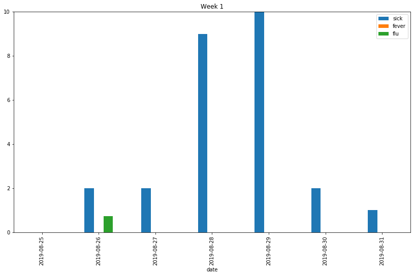

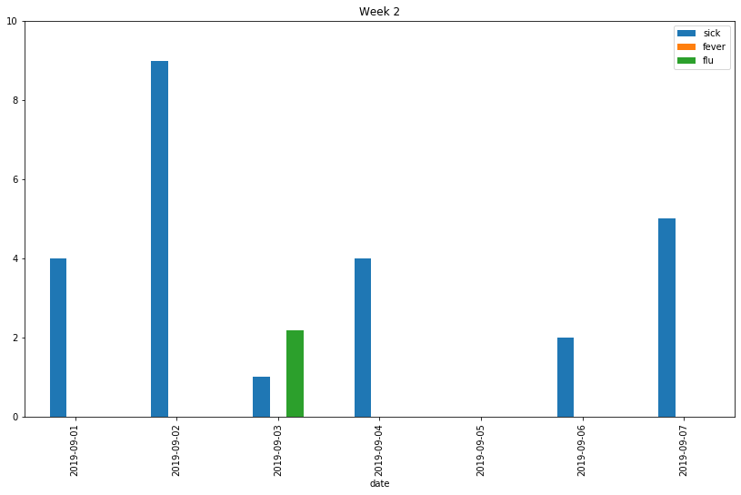

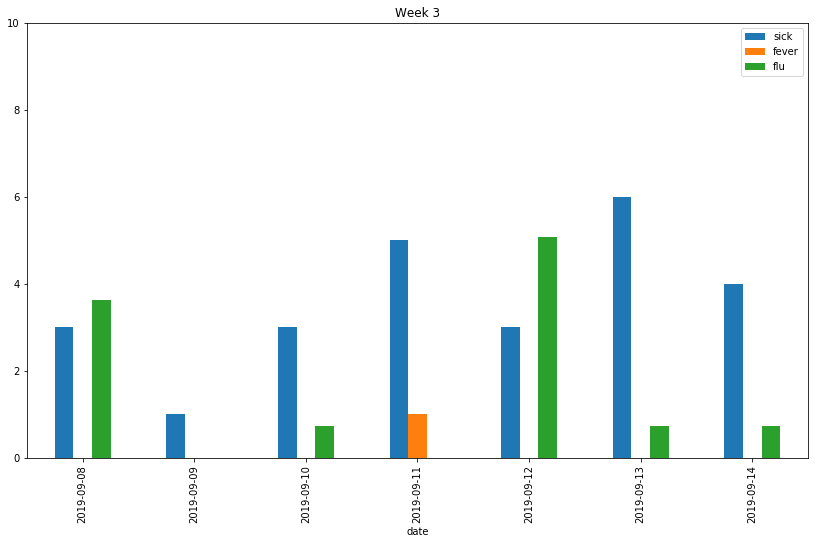

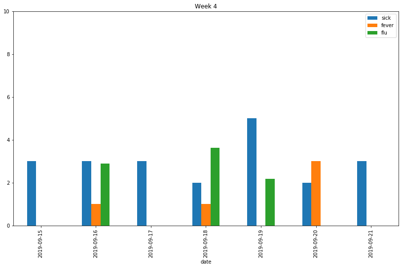

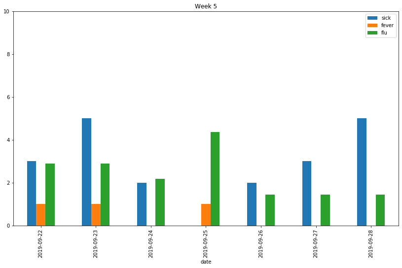

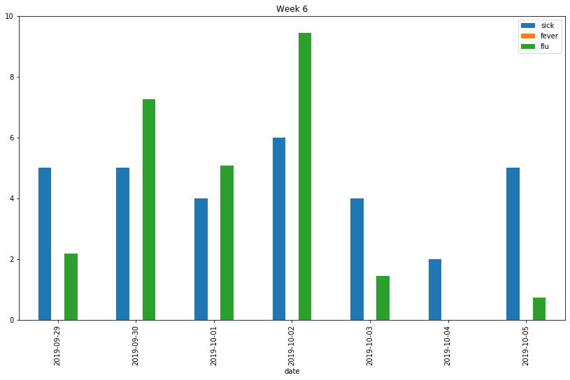

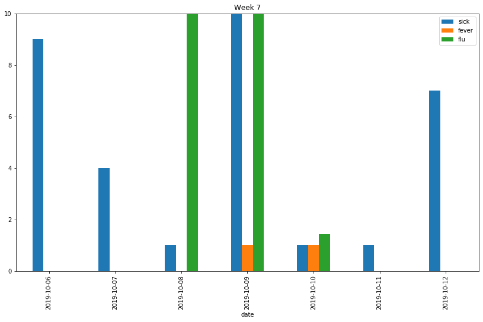

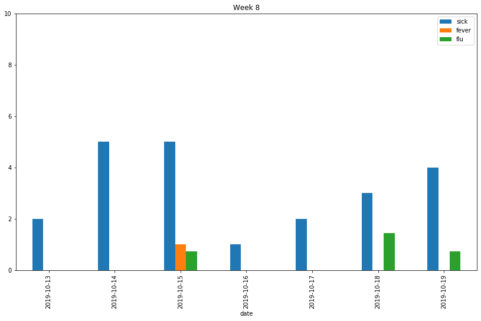

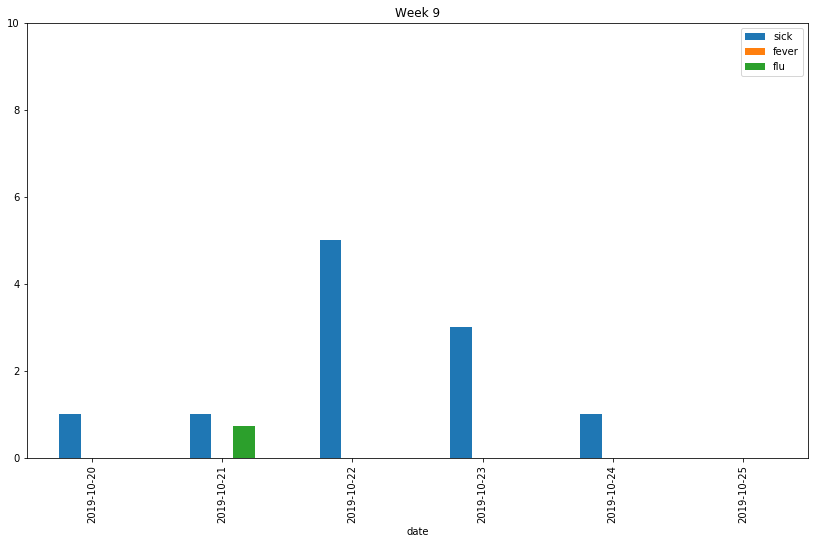

```python
# The following graphs show from Week 1 (August 25, 2019) to Week 9 (October 25, 2019) the Term Frequencies of the terms "sick", "fever", and "flu".

import matplotlib.pyplot as plt

for i in range(0,TF.shape[0],7):
    weekdf = pd.DataFrame({'Date':TF.index.tolist()[i:i+7], 'sick':TF.sick[i:i+7], 'fever':TF.fever[i:i+7], 'flu':TFIDF.flu[i:i+7]})
    ax = weekdf.plot.bar(figsize=(14,8))
    ax.set_ylim(0,10)

    ax.set_title('Week ' + str(int(i/7+1)))
```

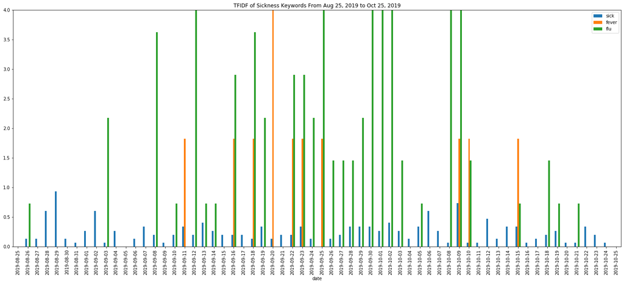

```python
# Next we explore the TFIDF of these terms over the course of the 9 weeks.

weekdf = pd.DataFrame({'Date':TFIDF.index.tolist(), 'sick':TFIDF.sick, 'fever':TFIDF.fever, 'flu':TFIDF.flu})
ax = weekdf.plot.bar(figsize=(25,10))
ax.set_ylim(0,4)
ax.set_title('TFIDF of Sickness Keywords From Aug 25, 2019 to Oct 25, 2019');
```